[figure not shown]

Gus Lipkin

2023-02-11

# What is cipheR and why?

- [`cipheR`](https://cran.r-project.org/web/packages/cipheR/index.html) is a package for simple text ciphers.
  - A cipher is text that has been transformed by some method with the intention of hiding its meaning
- I made it because I needed a flexible [Caesar Cipher](https://en.wikipedia.org/wiki/Caesar_cipher) for [Advent of Code](https://adventofcode.com/)

To install from CRAN

```r
install.packages("cipheR")
```

# What I’m hoping you learn

- Some cool new text ciphers perfect for passing notes in class
- Base R methods to deal with text
- Writing speedy code with `apply`

# What I’m hoping to get feedback on

- Error handling (and if we have time, testing)
- UX and how best to work with vector inputs
- What kinds of code comments people expect in open source
- Any spots where I can swap an `apply` for vectorization

# Caesar Cipher

- Description: This can be used to create (encrypt) and solve (decrypt) a Caesar cipher. The function does not differentiate between the two.
- Differentiator: You can choose your dictionary to shift by.

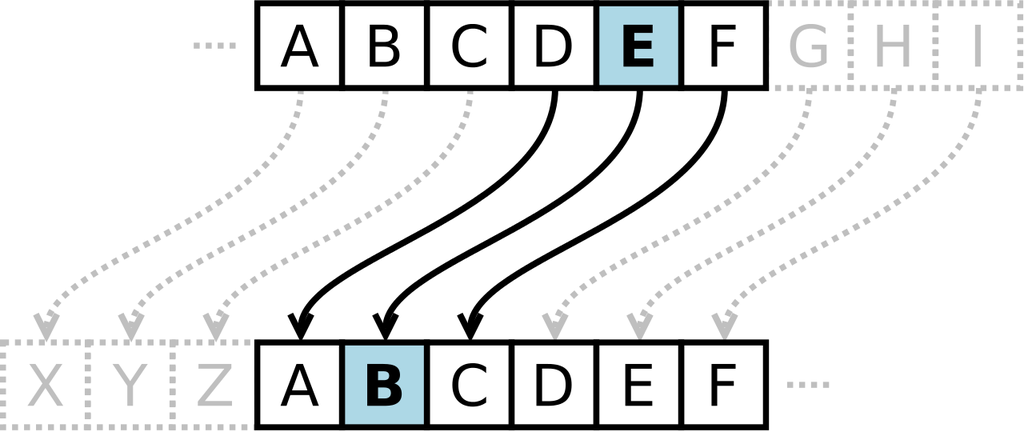

## Parameters

- `x` A vector to be shifted
- `n` The number of places to shift by. This can be either positive or negative. Zero returns x as it was given to the function.
- `preserve_spaces` (Default: `TRUE`) A boolean describing if spaces should be preserved. This is helpful when working with sentences.
- `dict` The dictionary used for shifting. This defaults to NULL in which case a dictionary is built from the sorted unique values of `x`.
- `preset` A pre-made dictionary using ASCII codes from [ascii-code.com](https://www.ascii-code.com/). Note that `delete` is excluded as a character.
- The options are to only use provided characters (`NULL`), `alphanumeric`, `keyboard`, `letters`, `lowercase`, `uppercase`. Characters are US English.

## Examples

```r
(e1 <- caesar("abcde", 1))
```

```
[1] "bcdea"
```

```r
caesar(e1, -1)
```

```
[1] "abcde"
```

```r
(e2 <- caesar("cipheR is a great R package!", -5))
```

```
[1] "Rae!sh ai r tgsrk h erRcrtsp"
```

```r
caesar(e2, 5)
```

```
[1] "cipheR is a great R package!"
```

```r
(e3 <- caesar("Isn't this fun?", 2, preserve_spaces = FALSE))
```

```
[1] "suth ' Inu'i?tf"
```

```r
caesar(e3, -2, preserve_spaces = FALSE)
```

```
[1] "Isn't this fun?"
```

## `caesar.R`

```r
caesar <- function(x, n = 1, preserve_spaces = TRUE, dict = NULL, preset = NULL) {

  # Catching errors
  if (length(x) == 0) {
    stop("Please provide a vector of length greater than zero to shift.")
  } else if (!is.atomic(x) | !(is.character(x) | is.numeric(x))) {
    stop("x must be a numeric or character vector.")
  }

  if (!is.null(dict) & !is.null(preset)) {
    warning("Both a dict and a preset was provided, only the dict will be used.")
  }

  if (n == 0) {
    message("Shifting by zero doesn't do anything...")
    return(x)
  }

  if (!is.character(x)) { x <- as.character(x) }

  x <- strsplit(x, "")
  unlistX <- unlist(x)

  # Set the dictionary as needed
  if (is.null(dict) & is.null(preset)) {
    dict <- sort(unique(unlistX))
  } else if (!is.null(preset)) {
    if (preset == "alphanumeric")   { dict <- rawToChar(as.raw(c(48:57, 65:90, 97:122))) }
    else if (preset == "keyboard")  { dict <- rawToChar(as.raw(32:126)) }
    else if (preset == "letters")   { dict <- rawToChar(as.raw(c(65:90, 97:122))) }
    else if (preset == "lowercase") { dict <- rawToChar(as.raw(c(97:122))) }
    else if (preset == "uppercase") { dict <- rawToChar(as.raw(c(65:90))) }
    else {
      stop("It looks like you may have a typo in your presets.
            You can double-check the presets by running ?caesar in your console.")
    }
  }

  if (length(dict) == 1) { dict <- unlist(strsplit(dict, "")) }

  if (!all(unlistX %in% dict)) {
    stop("Not all values of x are in the character set. Please choose a different character set.")
  }

  x <- lapply(x, function(y) {
      # We need to preserve spaces as requested
      if (preserve_spaces) {
        isSpace <- which(dict == " ")
        if (length(isSpace > 0)) { dict <- dict[-which(dict == " ")] }
      }

      # Do the shifting
      y <- sapply(y, function(z) {
          if (preserve_spaces & z == " ") { return(" ") }
          hop <- which(z == dict) + n
          hop <- hop %% length(dict)
          if (hop == 0) { hop <- length(dict) }
          return(dict[hop])
        })
      y <- paste0(y, collapse = "")
      return(y)
    })

  x <- unlist(x, recursive = FALSE)

  return(x)
}
```

## `test-caesar.R`

```r
test_that("Shift 0 warns and works", {
  expect_message(caesar("abcde", 0))
  expect_equal(caesar("abcde", 0), "abcde")
})
test_that("Shift 1 works", {
  expect_equal(caesar("abcde", 1), "bcdea")
})
test_that("Shift -1 works", {
  expect_equal(caesar("abcde", -1), "eabcd")
})

test_that("Spaces are preserved", {
  expect_equal(caesar("a b c", 1), "b c a")
})
test_that("Spaces are not preserved", {
  expect_equal(caesar("a b c", 1, preserve_spaces = FALSE), "baca ")
})

test_that("Vector length is preserved", {
  expect_equal(caesar(c("a", "b", "c"), 1), c("b", "c", "a"))
})

test_that("When no dictionary is provided, x is used", {
  expect_equal(caesar("abcde", 1), "bcdea")
})

test_that("Cannot provide both a dict and a preset", {
  expect_warning(caesar("abcde", 1, dict = "abcde", preset = "letters"))
})

test_that("The alphanumeric preset works", {
  expect_equal(caesar("abc123", 1, preset = "alphanumeric"), "bcd234")
})
test_that("The keyboard preset works", {
  expect_equal(caesar("abc123!@#", 1, preset = "keyboard"), "bcd234\"A$")
})
test_that("The letters preset works", {
  expect_equal(caesar("abcABC", 1, preset = "letters"), "bcdBCD")
})
test_that("The lowercase preset works", {
  expect_equal(caesar("abcde", 1, preset = "lowercase"), "bcdef")
})
test_that("The uppercase preset works", {
  expect_equal(caesar("ABCDE", 1, preset = "uppercase"), "BCDEF")
})
test_that("A typo in the preset gives an error", {
  expect_error(caesar("abc", 1, preset = "abc"))
})

test_that("dict must contain all values in x", {
  expect_error(caesar("abc", 1, dict = "def"))
})

test_that("x cannot be empty", {
  expect_error(caesar(c(), 1))
})
test_that("x must be a vector", {
  expect_error(caesar(list("abc"), 1))
})
test_that("x must be a character or numeric vector", {
  expect_error(caesar(c(TRUE), 1))
})
```

# Atbash Cipher

| a | b | c | d | … |
| --- | --- | --- | --- | --- |
| z | y | x | w | … |

## Parameter

- `x` A vector to be encoded or decoded

## Examples

```r
(e1 <- atbash("abcde"))
```

```
[1] "zyxwv"
```

```r
atbash(e1)
```

```
[1] "abcde"
```

```r
(e2 <- atbash("cipheR is a great R package!"))
```

```
[1] "xrksvI rh z tivzg I kzxpztv!"
```

```r
atbash(e2)
```

```
[1] "cipheR is a great R package!"
```

```r
(e3 <- atbash("Isn't this fun?"))
```

```
[1] "Rhm'g gsrh ufm?"
```

```r
atbash(e3)
```

```
[1] "Isn't this fun?"
```

## `atbash.R`

```r
atbash <- function(x) {

  if (length(x) == 0) {
    stop("Please provide a vector of length greater than zero.")
  } else if (!is.atomic(x) & !is.character(x)) {
    stop("x must be a character vector.")
  }

  x <- strsplit(x, "")

  x <- lapply(x, function(y) {
    y <- sapply(y, function(z) {
        if (z %in% c(letters, LETTERS)) {
          if (grepl("[A-Z]", z)) { z <- LETTERS[27 - which(LETTERS == z)] }
          else { z <- letters[27 - which(letters == z)] }
        }
        return(z)
      })
    y <- paste0(y, collapse = "")
    return(y)
  })

  x <- unlist(x, recursive = FALSE)

  return(x)
}
```

## `test-atbash.R`

```r
test_that("Letters are flipped", {
  expect_equal(atbash("az"), "za")
})

test_that("Spaces are preserved", {
  expect_equal(atbash("a b c"), "z y x")
})
test_that("Punctuation is preserved", {
  expect_equal(atbash("a.b"), "z.y")
})

test_that("Vector length is preserved", {
  expect_equal(atbash(c("a", "b", "c")), c("z", "y", "x"))
})

test_that("Must be a character vector of length greater than zero", {
  expect_error(atbash(c(TRUE)))
  expect_error(atbash(c(123)))
  expect_error(atbash(c()))
})
```

# Rail Fence Cipher

- Description: This can be used to create (encrypt) and solve (decrypt) a Railfence Cipher. A Railfence Cipher maps each letter to a cosine wave of the specified height where each letter resides at an integer rail height.

CAN YOU READ ME

| C | - | - | - | - | - | U | - | - | - | - | - |  | - | - |
| --- | --- | --- | --- | --- | --- | --- | --- | --- | --- | --- | --- | --- | --- | --- |
| - | A | - | - | - | O | - |  | - | - | - | D | - | M | - |
| - | - | N | - | Y | - | - | - | R | - | A | - | - | - | E |
| - | - | - |  | - | - | - | - | - | E | - | - | - | - | - |

CU AO DMNYRAE E

## Parameters

- `x` A vector to be encoded or decoded
- `n` (Default: `1`) The width of the rail to be used. A width of one will have no effect.
- `decrypt` (Default: `FALSE`) The default `FALSE` will encrypt while using `TRUE` will decrypt a given value of `x`.

## Examples

```r
(e1 <- railfence("abcde", 2))
```

```
[1] "acebd"
```

```r
railfence(e1, 2, decrypt = TRUE)
```

```
[1] "abcde"
```

```r
(e2 <- railfence("cipheR is a great R package!", 4))
```

```
[1] "c gRaiRi r  kgpesaetpceh aa!"
```

```r
railfence(e2, 4, decrypt = TRUE)
```

```
[1] "cipheR is a great R package!"
```

```r
(e3 <- railfence("Isn't this fun?", 3))
```

```
[1] "Itius' hsfnnt ?"
```

```r
railfence(e3, 3, decrypt = TRUE)
```

```
[1] "Isn't this fun?"
```

## `railfence.R`

```r
railfence <- function(x, n = 1, decrypt = FALSE) {

  if (length(x) == 0) { stop("Please provide a vector of length greater than zero") }
  else if (!is.atomic(x) & !is.character(x)) { stop("x must be a character vector.") }

  if (length(n) != 1 || n < 1 || n %% 1 != 0) {
    stop("n must be a single integer greater than or equal to 1")
  }

  if (!is.logical(decrypt)) { stop("decrypt must be logical") }

  if (!decrypt) { x <- .railfence_encrypt(x, n) }
  else { x <- .railfence_decrypt(x, n) }

  return(x)
}

#' @keywords internal
.railfence_encrypt <- function(x, n) {
  x <- strsplit(x, "")

  x <- lapply(x, function(y) {
    nx <- length(y)
    z <- c(1, rep_len(c(2:n, (n - 1):1), nx - 1))
    y <- data.frame("x" = y, "pos" = z)
    y <- y[order(y$pos), ]
    y <- paste0(y$x, collapse = "")
    return(y)
  })

  x <- unlist(x, recursive = FALSE)

  return(x)
}

#' @keywords internal
.railfence_decrypt <- function(x, n) {
  x <-
    lapply(x, function(s) {
      s <- unlist(strsplit(s, ""))
      m <- matrix(NA, n, length(s))
      j <- 1
      dir <- 1
      for (i in 1:length(s)) {
        m[j, i] <- "*"

        if (dir == 1) {
          if (j == n) {
            dir <- -1
            j <- j - 1
          } else {
            j <- j + 1
          }
        } else {
          if (j == 1) {
            dir <- 1
            j <- j + 1
          } else {
            j <- j - 1
          }
        }
      }
      k <- 1
      for (j in 1:nrow(m)) {
        for (i in 1:ncol(m)) {
          if (!is.na(m[j, i])) {
            m[j, i] <- s[k]
            k <- k + 1
          }
        }
      }
      m <- as.vector(m)
      m <- paste(m[!is.na(m)], collapse = "")

      return(m)
    })

  x <- unlist(x, recursive = FALSE)

  return(x)
}
```

## `test-railfence.R`

```r
test_that("encryption works", {
  expect_equal(railfence("abc def ghij", 3), "adgb e hjcfi")
  expect_equal(railfence(c("abc", "def", "ghij"), 2), c("acb", "dfe", "gihj"))
})
test_that("decryption works", {
  expect_equal(railfence("adgb e hjcfi", 3, decrypt = TRUE), "abc def ghij")
  expect_equal(railfence(c("acb", "dfe", "gihj"), 2, decrypt = TRUE),
               c("abc", "def", "ghij"))
})

test_that("must be a vector with length > 0", {
  expect_error(railfence(c(), 3))
  expect_error(railfence(matrix(NA, 1, 1), 3))
})

test_that("n must be a single integer greater than or equal to 1", {
  expect_error(railfence("abc", 0))
  expect_error(railfence("abc", 1.5))
  expect_error(railfence("abc", 0:3))
})

test_that("decrypt must be logical", {
  expect_error(railfence("abc", 3, "true"))
})
```

# Vigenere Cipher

- Description: This can be used to create (encrypt) and solve (decrypt) a Vigenere Cipher. A Vigenere cipher uses a table of alphabetic Caesar shifts for one to twenty-six. Each letter and corresponding key value determine the grid location to choose the obfuscated letter from.

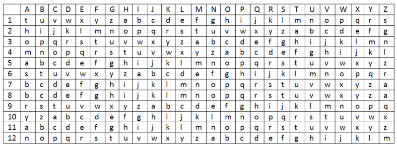

## Parameters

- `x` A vector to be encoded or decoded.
- `key` A character vector of length one to use as a key
- `decrypt` (Default: `FALSE`) The default `FALSE` will encrypt while using `TRUE` will decrypt a given value of `x`.
- `keep_punctuation` (Default: `FALSE`) The default `FALSE` will ignore case and punctuation and return a lowercase result. `TRUE` will match the input’s case and punctuation.

## Examples

```r
(e1 <- vigenere("abcde", "key"))
```

```
[1] "kfani"
```

```r
vigenere(e1, "key", decrypt = TRUE)
```

```
[1] "abcde"
```

```r
(e2 <- vigenere("cipheR is a great R package!", "key"))
```

```
[1] "mmnripswyqvckxpzeaueeo"
```

```r
vigenere(e2, "key", decrypt = TRUE)
```

```
[1] "cipherisagreatrpackage"
```

```r
(e3 <- vigenere("Isn't this fun?", "key", keep_punctuation = TRUE))
```

```
[1] "'"
[1] " "
[1] " "
[1] "?"
```

```
[1] "Swl'd xfsw der?"
```

```r
vigenere(e3, "key", decrypt = TRUE, keep_punctuation = TRUE)
```

```
[1] "Isn't this fun?"
```

## `vigenere.R`

```r
vigenere <- function(x, key, decrypt = FALSE, keep_punctuation = FALSE) {

  if (length(x) == 0) {
    stop("Please provide a vector of length greater than zero for x")
  } else if (!is.atomic(x) & !is.character(x) & !is.matrix(x)) {
    stop("x must be a character vector.")
  }

  if (length(key) != 1) {
    stop("Please provide a vector of length one for key")
  } else if (!is.character(key) & (is.matrix(key) | !is.atomic(key))) {
    stop("key must be a character vector.")
  }

  if (!is.logical(decrypt)) {
    stop("decrypt must be logical")
  }
  if (!is.logical(keep_punctuation)) {
    stop("decrypt must be logical")
  }

  square <-
    suppressMessages(matrix(sapply(0:25, function(x) {
      caesar(letters, x)
    }), 26, 26))

  key <- tolower(key)

  if (!decrypt) {
    x <- .vigenere_encrypt(x, key, square, keep_punctuation)
  } else {
    x <- .vigenere_decrypt(x, key, square, keep_punctuation)
  }

  return(x)
}

#' @keywords internal
.vigenere_encrypt <- function(x, key, square, keep_punctuation) {
  x <- lapply(x, function(x) {
    x <- unlist(strsplit(x, ""))
    if (!keep_punctuation) { x <- x[grepl("[A-z]", x)] }
    lowerX <- tolower(x)

    key <- unlist(strsplit(key, ""))
    key <- .rep_key(x, key)
    r <- sapply(key, .get_letter)
    c <- sapply(lowerX, .get_letter)

    x <- sapply(1:length(x), function(i) {
      if (c[i] == 0) { y <- x[i] }
      else { y <- square[r[i], c[i]] }
      if (keep_punctuation & grepl("[A-Z]", x[i])) { return(toupper(y)) }
      else { return(y) }
    })
    x <- paste0(x, collapse = "")
    return(x)
  })
  x <- unlist(x, recursive = FALSE)
  return(x)
}

#' @keywords internal
.vigenere_decrypt <- function(x, key, square, keep_punctuation) {
  x <- lapply(x, function(x) {
    x <- unlist(strsplit(x, ""))
    if (!keep_punctuation) { x <- x[grepl("[A-z]", x)] }
    lowerX <- tolower(x)

    key <- unlist(strsplit(key, ""))
    key <- .rep_key(x, key)
    r <- sapply(key, .get_letter)

    x <- mapply(function(r, x, lowerX) {
      i <- square[1, which(square[r, ] == lowerX)]
      if (keep_punctuation & grepl("[A-Z]", x)) { i <- toupper(i) }
      else if (keep_punctuation & length(i) == 0) { i <- x }
      return(i)
    }, r, x, lowerX)
    x <- paste0(x, collapse = "")
    return(x)
  })
  x <- unlist(x, recursive = FALSE)
  return(x)
}

#' @keywords internal
.get_letter <- function(y) {
  y <- which(letters == y)
  if (length(y) == 0) { return(0) }
  else { return(y) }
}

#' @keywords internal
.rep_key <- function(x, key) {
  rep_key <- c()
  k <- 1
  return_key <- sapply(1:length(x), function(i) {
    ki <- k %% length(key)
    if (ki == 0) { ki <- length(key) }

    if (!grepl("[A-z]", x[i])) {
      rep_key <- c(rep_key, "")
    } else {
      rep_key <- c(rep_key, key[ki])
      k <<- k + 1
    }
    return(rep_key)
  })

  return(return_key)
}
```

## `test-vigenere.R`

```r
test_that("Punctuation is preserved for encryption", {
  expect_equal(vigenere("Test.message", "key", keep_punctuation = TRUE), "Diqd.qccwyqi")
  expect_equal(vigenere("testmessage", "key", keep_punctuation = FALSE), "diqdqccwyqi")
})
test_that("Punctuation is not preserved for encryption", {
  expect_equal(vigenere("Test.message", "key", keep_punctuation = FALSE), "diqdqccwyqi")
  expect_equal(vigenere("testmessage", "key", keep_punctuation = FALSE), "diqdqccwyqi")
})

test_that("Punctuation is preserved for decryption", {
  expect_equal(vigenere("Diqd.qccwyqi", "key", decrypt = TRUE, keep_punctuation = TRUE), "Test.message")
  expect_equal(vigenere("diqdqccwyqi", "key", decrypt = TRUE, keep_punctuation = TRUE), "testmessage")
})
test_that("Punctuation is not preserved for decryption", {
  expect_equal(vigenere("Diqd.qccwyqi", "key", decrypt = TRUE, keep_punctuation = FALSE), "testmessage")
  expect_equal(vigenere("diqdqccwyqi", "key", decrypt = TRUE, keep_punctuation = TRUE), "testmessage")
})

test_that("x must be a vector with length > 0", {
  expect_error(vigenere(c(), "key"))
  expect_error(vigenere(matrix(NA, 1, 1), "key"))
})
test_that("key must be a vector with length == 1", {
  expect_error(vigenere("testmessage", c()))
  expect_error(vigenere("testmessage", matrix(NA, 1, 1)))
})

test_that("decrypt must be a boolean", {
  expect_equal(vigenere("Test.message", "key", decrypt = FALSE, keep_punctuation = TRUE), "Diqd.qccwyqi")
  expect_equal(vigenere("Diqd.qccwyqi", "key", decrypt = TRUE, keep_punctuation = TRUE), "Test.message")
  expect_error(vigenere("testmessage", "key", decrypt = 1))
})

test_that("keep_punctuation must be a boolean", {
  expect_equal(vigenere("Test.message", "key", decrypt = FALSE, keep_punctuation = TRUE), "Diqd.qccwyqi")
  expect_equal(vigenere("Diqd.qccwyqi", "key", decrypt = TRUE, keep_punctuation = FALSE), "testmessage")
  expect_error(vigenere("testmessage", "key", keep_punctuation = 1))
})
```

# Running Key Cipher

| Plaintext | R |  | i | s |  | g | r | e | a | t |
| --- | --- | --- | --- | --- | --- | --- | --- | --- | --- | --- |
| Running key | a | l | l |  | a | g | r | e | e | a |
| Ciphertext | R |  | t | d |  | g | x | v | e | x |

**Note**

Can we take a look at the description. Is there a more concise way to communicate this?

## Parameters

These are the same as the parameters for `vigenere()` because `running_key()` is just a modified version.

- `x` A vector to be encoded or decoded.
- `key` A character vector of length one to use as a key
- `decrypt` (Default: `FALSE`) The default `FALSE` will encrypt while using `TRUE` will decrypt a given value of `x`.
- `keep_punctuation` (Default: `FALSE`) The default `FALSE` will ignore case and punctuation and return a lowercase result. `TRUE` will match the input’s case and punctuation.

## Examples

```r
key <- "thisismysupersecurekey"
(e1 <- running_key("abcde", key))
```

```
[1] "tikvm"
```

```r
running_key(e1, key, decrypt = TRUE)
```

```
[1] "abcde"
```

```r
(e2 <- running_key("cipheR is a great R package!", key))
```

```
[1] "vpxzmjuqsagirlvrutokkc"
```

```r
running_key(e2, key, decrypt = TRUE)
```

```
[1] "cipherisagreatrpackage"
```

```r
(e3 <- running_key("Isn't this fun?", key, keep_punctuation = TRUE))
```

```
[1] "'"
[1] " "
[1] " "
[1] "?"
```

```
[1] "Bzv'l bzuq xoc?"
```

```r
running_key(e3, key, decrypt = TRUE, keep_punctuation = TRUE)
```

```
[1] "Isn't this fun?"
```

## `running_key.R`

```r
running_key <- function(x, key, decrypt = FALSE, keep_punctuation = FALSE) {
  if (length(x) != 1) { stop("Please provide a vector of length one for x")
  } else if (!is.atomic(x) & !is.character(x) & !is.matrix(x)) {
    stop("x must be a character vector.")
  }

  if (length(key) != 1) { stop("Please provide a vector of length one for key")
  } else if (!is.character(key) & (is.matrix(key) | !is.atomic(key))) {
    stop("key must be a character vector.")
  }

  y <- unlist(strsplit(x, ""))
  y <- y[grepl("[A-z]", y)]

  k <- unlist(strsplit(key, ""))
  k <- k[grepl("[A-z]", k)]

  if(length(k) >= length(y)) {
    x <- vigenere(x, paste0(k, collapse = ""), decrypt = decrypt, keep_punctuation = keep_punctuation)
    return(x)
  } else {
    stop(paste("The key must have an equal or greater number of letters to the text. The key has",
               length(k), "characters and the message has", length(y), "characters."))
  }
}
```

## `test-running_key.R`

```r
test_that("Encryption works", {
  expect_equal(running_key("testmessage", "thisisakeytothecipher"), "mlaluwsceex")
})

test_that("Decryption works", {
  expect_equal(running_key("mlaluwsceex", "thisisakeytothecipher", decrypt = TRUE), "testmessage")
})

test_that("Key must be longer than x", {
  expect_error(running_key("testmessage", "key"))
})
```

# What I’m hoping to get feedback on

Do your worst! Or best, constructive criticism is always good.

- Error handling (and if we have time, testing)
- UX and how best to work with vector inputs
- What kinds of code comments people expect in open source
- Any spots where I can swap an `apply` for vectorization

# Questions I have for you guys

- What is the best way to handle moving validation into their own functions? Do they get their own R file and they’re all marked as internal?